# Immigration in AU

2025-12-08

## **Setup**

Install and load the packages you need to produce the report here:

```r
# Importing necessary libraries
library(readr) # Useful for importing data
library(foreign) # Useful for importing SPSS, SAS, STATA etc. data files
library(rvest) # Useful for scraping HTML data
library(knitr) # Useful for creating nice tables
library(tidyverse)
```

```r
library(readxl)
library(ggplot2)
library(patchwork)
```

### **Data Description**

The dataset used in this analysis is sourced from the Australian Bureau of Statistics (ABS) and is part of the Overseas Arrivals and Departures, Australia collection. It provides official statistics on international movement into Australia over time, capturing both permanent and temporary arrivals.

The data focuses on total movements to Australia, disaggregated by visa type and residency status, allowing for analysis of long-term trends in migration and travel patterns.

The dataset can be accessed via the ABS website at: [ABS](https://www.abs.gov.au/statistics/industry/tourism-and-transport/overseas-arrivals-and-departures-australia/latest-release#data-downloads)

#### Variables

The dataset contains the following key variables:

- Date – Monthly observation date
- Year – Calendar year extracted from the date
- Permanent Arrivals – Number of permanent migrants arriving in Australia
- Long-term Residents Returning – Australian residents returning after long-term travel
- Long-term Visitors Arriving – Overseas visitors arriving for long-term stays
- Permanent and Long-term Arrivals – Combined permanent and long-term arrivals
- Short-term Residents Returning – Residents returning after short-term travel
- Short-term Visitors Arriving – Overseas visitors arriving for short-term stays
- Total Arrivals – Total number of arrivals across all categories

## 1. **Import Data**

First, we will import the dataset.

```
## # A tibble: 6 × 12
##   Date                Number of movements ;  Permanent …¹ Number of movements …²
##   <dttm>                                            <dbl>                  <dbl>
## 1 1976-01-01 00:00:00                                3780                   5380
## 2 1976-02-01 00:00:00                                3900                   4190
## 3 1976-03-01 00:00:00                                4790                   4250
## 4 1976-04-01 00:00:00                                3790                   3490
## 5 1976-05-01 00:00:00                                4680                   4190
## 6 1976-06-01 00:00:00                                3720                   3620
## # ℹ abbreviated names: ¹`Number of movements ;  Permanent Arrivals ;`,
## #   ²`Number of movements ;  Long-term Residents returning ;`
## # ℹ 9 more variables:
## #   `Number of movements ;  Long-term Visitors arriving ;` <dbl>,
## #   `Number of movements ;  Permanent and Long-term Arrivals ;` <dbl>,
## #   `Number of movements ;  Short-term Residents returning ;` <dbl>,
## #   `Number of movements ;  Short-term Residents returning ;` <dbl>, …
```

### **Inspect dataset and variables**

This section represents the EDA of our dataset. We will not modify the original dataset and instead look at a copy of our original data. All data preprocessing steps will be taken in the later ‘Tidy data’ section.

- Check structure
- Data types / column names
- Missing values / do zero values exist
- Histogram of shape, EDA outliers
- Check categorical data - levels

```r
# Dataframe structure
data <- df # only works due to R's copy-on-modity (copy-on-write) semantic
glimpse(data)
```

```
## Rows: 598
## Columns: 12
## $ Date                                                        <dttm> 1976-01-0…
## $ `Number of movements ;  Permanent Arrivals ;`               <dbl> 3780, 3900…
## $ `Number of movements ;  Long-term Residents returning ;`    <dbl> 5380, 4190…
## $ `Number of movements ;  Long-term Visitors arriving ;`      <dbl> 2750, 2730…
## $ `Number of movements ;  Permanent and Long-term Arrivals ;` <dbl> 11910, 108…
## $ `Number of movements ;  Short-term Residents returning ;`   <dbl> 143370, 76…
## $ `Number of movements ;  Short-term Residents returning ;`   <lgl> NA, NA, NA…
## $ `Number of movements ;  Short-term Residents returning ;`   <lgl> NA, NA, NA…
## $ `Number of movements ;  Short-term Visitors arriving ;`     <dbl> 47710, 498…
## $ `Number of movements ;  Short-term Visitors arriving ;`     <lgl> NA, NA, NA…
## $ `Number of movements ;  Short-term Visitors arriving ;`     <lgl> NA, NA, NA…
## $ `Number of movements ;  Total Arrivals ;`                   <dbl> 202990, 13…
```

```r
# Check missing values
cat("Missing total values:", sum(is.na(data)),'\n')
```

```
## Missing total values: 2392
```

```r
# Check NA per column
sapply(data, function(x) sum(is.na(x)))
```

```
##                                                      Date
##                                                         0
##               Number of movements ;  Permanent Arrivals ;
##                                                         0
##    Number of movements ;  Long-term Residents returning ;
##                                                         0
##      Number of movements ;  Long-term Visitors arriving ;
##                                                         0
## Number of movements ;  Permanent and Long-term Arrivals ;
##                                                         0
##   Number of movements ;  Short-term Residents returning ;
##                                                         0
##   Number of movements ;  Short-term Residents returning ;
##                                                       598
##   Number of movements ;  Short-term Residents returning ;
##                                                       598
##     Number of movements ;  Short-term Visitors arriving ;
##                                                         0
##     Number of movements ;  Short-term Visitors arriving ;
##                                                       598
##     Number of movements ;  Short-term Visitors arriving ;
##                                                       598
##                   Number of movements ;  Total Arrivals ;
##                                                         0
```

```r
# Check total rows
cat("\nTotal rows:",nrow(data))
```

```
##
## Total rows: 598
```

All logical columns contain 598 of missing values - all entries are `NA`. The best practice for our data preprocessing would be to drop those columns are they don’t contain any information. Since all columns have the identical name, it is very likely those columns were replicated by error.

Next, let’s check our column names:

```r
# Column names
names(data)
```

```
##  [1] "Date"
##  [2] "Number of movements ;  Permanent Arrivals ;"
##  [3] "Number of movements ;  Long-term Residents returning ;"
##  [4] "Number of movements ;  Long-term Visitors arriving ;"
##  [5] "Number of movements ;  Permanent and Long-term Arrivals ;"
##  [6] "Number of movements ;  Short-term Residents returning ;"
##  [7] "Number of movements ;  Short-term Residents returning ;"
##  [8] "Number of movements ;  Short-term Residents returning ;"
##  [9] "Number of movements ;  Short-term Visitors arriving ;"
## [10] "Number of movements ;  Short-term Visitors arriving ;"
## [11] "Number of movements ;  Short-term Visitors arriving ;"
## [12] "Number of movements ;  Total Arrivals ;"
```

We should amend the column names to for easier reference and understanding. In our data preprocessing, it might be best practice to shorten the column names - e.g. “Number of movements ; Permanent Arrivals ;” to “Permanent Arrivals”.

Let’s continue by exploring if any columns contain an excessive amount of zero-values:

```r
library(lubridate)
library(dplyr)
# Get the year of each row
data$Year <- lubridate::year(data$Date)

# Exclude the NA columns
subset_data = data[, colSums(is.na(data)) == 0]
subset_data
```

```
## # A tibble: 598 × 9
##    Date                Number of movements ;  Permanent…¹ Number of movements …²
##    <dttm>                                           <dbl>                  <dbl>
##  1 1976-01-01 00:00:00                               3780                   5380
##  2 1976-02-01 00:00:00                               3900                   4190
##  3 1976-03-01 00:00:00                               4790                   4250
##  4 1976-04-01 00:00:00                               3790                   3490
##  5 1976-05-01 00:00:00                               4680                   4190
##  6 1976-06-01 00:00:00                               3720                   3620
##  7 1976-07-01 00:00:00                               4600                   4720
##  8 1976-08-01 00:00:00                               4750                   5130
##  9 1976-09-01 00:00:00                               4470                   4740
## 10 1976-10-01 00:00:00                               6070                   5550
## # ℹ 588 more rows
## # ℹ abbreviated names: ¹`Number of movements ;  Permanent Arrivals ;`,
## #   ²`Number of movements ;  Long-term Residents returning ;`
## # ℹ 6 more variables:
## #   `Number of movements ;  Long-term Visitors arriving ;` <dbl>,
## #   `Number of movements ;  Permanent and Long-term Arrivals ;` <dbl>,
## #   `Number of movements ;  Short-term Residents returning ;` <dbl>, …
```

```r
# Checking zero values
zero_values <- subset_data |> group_by(Year) |>
  summarise(
    across(
      where(is.numeric),
      ~ sum(. == 0, na.rm = TRUE),
      .names = "zeros_{.col}"
    ),
    .groups = 'drop'
)

head(zero_values)
```

```
## # A tibble: 6 × 8
##    Year zeros_Number of movement…¹ zeros_Number of move…² zeros_Number of move…³
##   <dbl>                      <int>                  <int>                  <int>
## 1  1976                          0                      0                      0
## 2  1977                          0                      0                      0
## 3  1978                          0                      0                      0
## 4  1979                          0                      0                      0
## 5  1980                          0                      0                      0
## 6  1981                          0                      0                      0
## # ℹ abbreviated names: ¹`zeros_Number of movements ;  Permanent Arrivals ;`,
## #   ²`zeros_Number of movements ;  Long-term Residents returning ;`,
## #   ³`zeros_Number of movements ;  Long-term Visitors arriving ;`
## # ℹ 4 more variables:
## #   `zeros_Number of movements ;  Permanent and Long-term Arrivals ;` <int>,
## #   `zeros_Number of movements ;  Short-term Residents returning ;` <int>,
## #   `zeros_Number of movements ;  Short-term Visitors arriving ;` <int>, …
```

```r
# Summarise the result
sum(zero_values[2:ncol(zero_values)])
```

```
## [1] 0
```

The whole dataset doesn’t contain any null-values.

Lastly, let’s check the distribution of the numerical values:

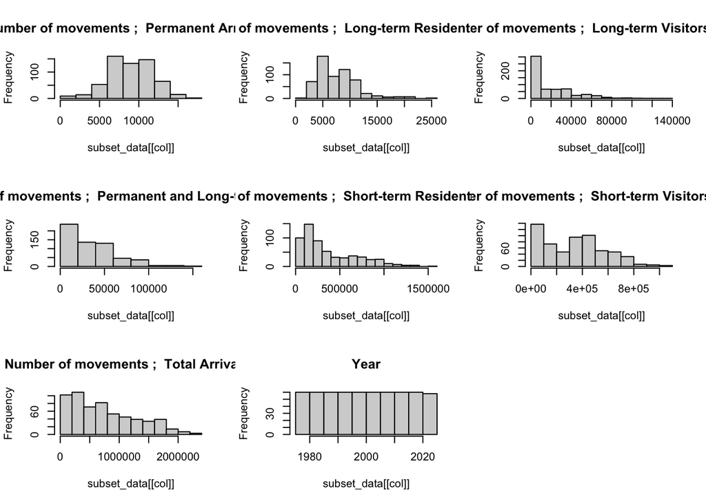

```r
# Drop columns
subset_data$Date <- NULL

# Loop over the columns
par(mfrow = c(3,3)) # Display 3x3 visuals
for (col in names(subset_data)) {
  hist(subset_data[[col]], main = col)
}
```

We can see that most of our data is right-skewed except for `Permanent Arrivals` and `Year`.

Since we do not have any categorical variables, we can now continue to clean and tidy our dataset. Let’s summarise the issues we encountered:

### **Tidy data**

This section focuses on the tidy principles by Wickham & Grolemund:

Typical steps for this section: - Create a copy of the dataset - Fix missing values (e.g. categorical with mode or ‘unknown’, numeric with mean) - Fix all previous discovered issues - Create summary statistics

Let’s start our preprocessing by creating another copy of our original dataset and amending the column names to be more precised:

```r
# Create a copy but ignores the columns with NA values, and adds the year
immigration <- df[, colSums(is.na(df)) == 0]
immigration$Year <- lubridate::year(immigration$Date)

# Fix the column names
names(immigration)
```

```
## [1] "Date"
## [2] "Number of movements ;  Permanent Arrivals ;"
## [3] "Number of movements ;  Long-term Residents returning ;"
## [4] "Number of movements ;  Long-term Visitors arriving ;"
## [5] "Number of movements ;  Permanent and Long-term Arrivals ;"
## [6] "Number of movements ;  Short-term Residents returning ;"
## [7] "Number of movements ;  Short-term Visitors arriving ;"
## [8] "Number of movements ;  Total Arrivals ;"
## [9] "Year"
```

```r
# Change the column names
new_column_names <- c("Permanent Arrivals", "Long-term_Residents returning", "Long-term Visitors arriving", "Permanent and Long-term Arrivals", "Short-term Residents returning", "Short-term Visitors arriving", "Total Arrivals")

colnames(immigration)[2:(ncol(immigration) - 1)] <- new_column_names

names(immigration)
```

```
## [1] "Date"                             "Permanent Arrivals"
## [3] "Long-term_Residents returning"    "Long-term Visitors arriving"
## [5] "Permanent and Long-term Arrivals" "Short-term Residents returning"
## [7] "Short-term Visitors arriving"     "Total Arrivals"
## [9] "Year"
```

Before we continue, let’s check if our dataset fullfills the 3rd rule - each cell must represent one value. In R, this will mean that no cell can contain e.g. a list:

```r
# Check if any row contains a cell with a list
vapply(immigration, is.list, logical(1))
```

```
##                             Date               Permanent Arrivals
##                            FALSE                            FALSE
##    Long-term_Residents returning      Long-term Visitors arriving
##                            FALSE                            FALSE
## Permanent and Long-term Arrivals   Short-term Residents returning
##                            FALSE                            FALSE
##     Short-term Visitors arriving                   Total Arrivals
##                            FALSE                            FALSE
##                             Year
##                            FALSE
```

Lastly, to further understand the full scale of `Total Arrivals`, let’s create some summary statistics:

```r
immigration |> group_by(Year) |>
  summarise(
    Mean_TA = mean(`Total Arrivals`),
    Median_TA = median(`Total Arrivals`),
    Min_TA = min(`Total Arrivals`),
    Max_TA = max(`Total Arrivals`),
    SD_TA = sd(`Total Arrivals`)
  )
```

```
## # A tibble: 50 × 6
##     Year Mean_TA Median_TA Min_TA Max_TA  SD_TA
##    <dbl>   <dbl>     <dbl>  <dbl>  <dbl>  <dbl>
##  1  1976 136792.    134545 100200 202990 28277.
##  2  1977 141481.    136845 108990 219630 30548.
##  3  1978 151233.    147245 115760 208540 27938.
##  4  1979 175400     174725 140470 228010 25226.
##  5  1980 190300     189210 157710 232240 18202.
##  6  1981 194232.    191770 169790 233160 16785.
##  7  1982 200792.    199645 176190 252320 20412.
##  8  1983 193092.    193280 167110 251190 24649.
##  9  1984 211942.    209640 177690 254240 25423.
## 10  1985 234155     225755 195590 281040 26742.
## # ℹ 40 more rows
```

Let’s see if there are any outliers. To ensure multiple boxplots are being formed, we will group Year into 5-year categories.

```r
immigration <- immigration |> mutate(year_cat = cut(
  Year,
  breaks = seq(min(Year), max(Year) + 5, by = 5),
  labels = c(
    "1975–79", "1980–84", "1985–89", "1990–94",
        "1995–99", "2000–04", "2005–09", "2010–14",
        "2015–19", "2020–24"),
  right = FALSE)
)
```

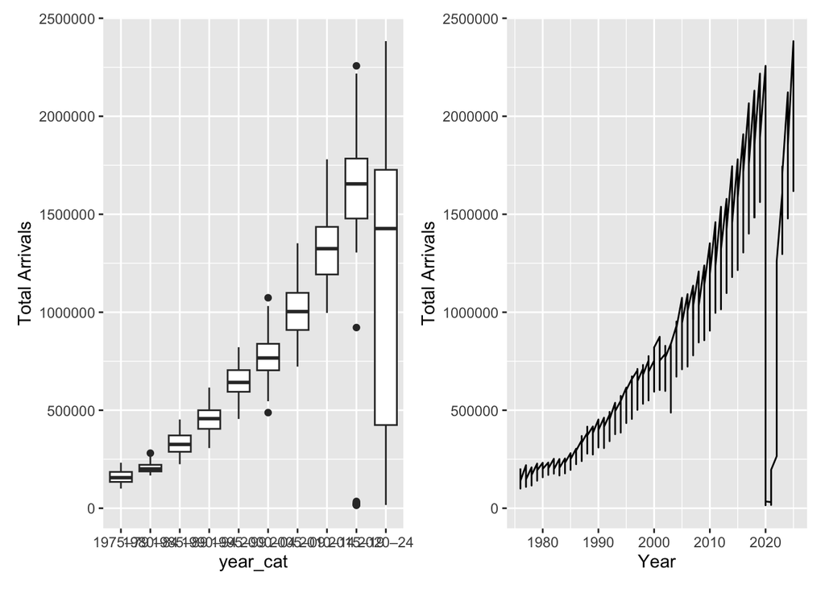

```r
# First plot
p1 <- ggplot(immigration, aes(x = year_cat, y = `Total Arrivals`)) +
  geom_boxplot()
# Comparison
p2 <- ggplot(immigration, aes(x=Year, y=`Total Arrivals`)) +
  geom_line()
# Display both using library `patchwork`
p1 | p2
```

### **Create a list**

We create a list `my_list` which will be a list of the variable `Total` named by `year_cat`.

```r
# Create a named list that summarises the `Total Arrivals` per year category
# Let's inspect what we want to have as a named list
summary_df <- immigration |> group_by(year_cat) |> summarise(Total = sum(`Total Arrivals`))
summary_df
```

```
## # A tibble: 10 × 2
##    year_cat    Total
##    <fct>       <dbl>
##  1 1975–79   9542480
##  2 1980–84  12410560
##  3 1985–89  19662550
##  4 1990–94  27353450
##  5 1995–99  38823930
##  6 2000–04  46297880
##  7 2005–09  60706370
##  8 2010–14  79744890
##  9 2015–19  86825590
## 10 2020–24  68498180
```

```r
my_list <- setNames(
  as.list(summary_df$Total), summary_df$year_cat)

my_list
```

```
## $`1975–79`
## [1] 9542480
##
## $`1980–84`
## [1] 12410560
##
## $`1985–89`
## [1] 19662550
##
## $`1990–94`
## [1] 27353450
##
## $`1995–99`
## [1] 38823930
##
## $`2000–04`
## [1] 46297880
##
## $`2005–09`
## [1] 60706370
##
## $`2010–14`
## [1] 79744890
##
## $`2015–19`
## [1] 86825590
##
## $`2020–24`
## [1] 68498180
```

### **Join the list**

We now convert our named list into a dataframe:

```r
# Create a data frame
data2 <- data.frame(
  `Year_cat` = names(my_list),
  `Total Immigration` = unlist(my_list))
# Remove row names
rownames(data2) <- NULL
# Display the result
head(data2)
```

```
##   Year_cat Total.Immigration
## 1  1975–79           9542480
## 2  1980–84          12410560
## 3  1985–89          19662550
## 4  1990–94          27353450
## 5  1995–99          38823930
## 6  2000–04          46297880
```

To join dataframes, let’s create a second dataframe that contains of the same `Year_cat` column but randomly assigns a country of origin to each year group - simulating which country migrated the most in that year period.

```r
# Excourse - let's create 10 random countries
set.seed(123)
str(data2)
```

```
## 'data.frame':    10 obs. of  2 variables:
##  $ Year_cat         : chr  "1975–79" "1980–84" "1985–89" "1990–94" ...
##  $ Total.Immigration: num  9542480 12410560 19662550 27353450 38823930 ...
```

```r
countries <- c("USA","Germany","France","Spain","Italy","Poland","Denmark","Sweden","China","India","NZ","Japan","Korea","Thailand","Indonesia")

data3 <- data.frame(
  `Year_cat` = names(my_list),
  `country` = sample(countries, nrow(data2), replace = TRUE))

head(data3)
```

```
##   Year_cat   country
## 1  1975–79 Indonesia
## 2  1980–84 Indonesia
## 3  1985–89    France
## 4  1990–94  Thailand
## 5  1995–99    France
## 6  2000–04     India
```

Let’s now join the dataframes:

```r
# Joined dataframe:
joined_df <- data2 |> left_join(data3, by = "Year_cat")
joined_df
```

```
##    Year_cat Total.Immigration   country
## 1   1975–79           9542480 Indonesia
## 2   1980–84          12410560 Indonesia
## 3   1985–89          19662550    France
## 4   1990–94          27353450  Thailand
## 5   1995–99          38823930    France
## 6   2000–04          46297880     India
## 7   2005–09          60706370   Germany
## 8   2010–14          79744890    Poland
## 9   2015–19          86825590        NZ
## 10  2020–24          68498180     Italy
```

### **Subsetting (first and last variable)**

Lastly, we crosscheck if our `Date` and `year_cat` variable are matching:

```r
# Subset the first and last variable
immigration |> dplyr::select(1, ncol(immigration))
```

```
## # A tibble: 598 × 2
##    Date                year_cat
##    <dttm>              <fct>
##  1 1976-01-01 00:00:00 1975–79
##  2 1976-02-01 00:00:00 1975–79
##  3 1976-03-01 00:00:00 1975–79
##  4 1976-04-01 00:00:00 1975–79
##  5 1976-05-01 00:00:00 1975–79
##  6 1976-06-01 00:00:00 1975–79
##  7 1976-07-01 00:00:00 1975–79
##  8 1976-08-01 00:00:00 1975–79
##  9 1976-09-01 00:00:00 1975–79
## 10 1976-10-01 00:00:00 1975–79
## # ℹ 588 more rows
```

This concludes the Assignment 1 of MATH2405 Data Wrangling - RMIT.